# Dimension reduction for CCLE dataset

# Summary

# Library and data preprocessing

First we’ll load some essential libraries.

```r
#install.packages(c('ggplot2', 'tidyverse', 'readxl'))
library(tidyverse)
library(ggplot2)
library(readxl)
library(reshape2)
```

Now let’s load the data.

```r
filepath = 'C:/Users/scott/Data/Mapped CCLE Metabolomics-GCP Data.xlsx'
met = read_xlsx(path=filepath, sheet='Metabolomics')
celllines = met[, 1]
met = met[, -1]
met = data.matrix(met)

gcp = read_xlsx(path=filepath, sheet='GCP')
gcp = gcp[, -1]
gcp = data.matrix(gcp)

meta = read_xlsx(path=filepath, sheet='Meta')
```

## Clean dataset

I’m only interested in single histone PTMs, so I need to clean up the GCP dataset.

```r
gcp_name = colnames(gcp)
pos_to_keep = c(3, 4, 5,
                7, 8, 9, 10,
                11, 17, 18,
                22, 23, 24,
                25, 29, 32,
                34, 42, 43) - 1
gcp_name = gcp_name[pos_to_keep]
```

Let’s clean up the labels using regular expressions.

```r
# Remove useless marks
gcp = gcp[, pos_to_keep]

# Remove regexes
pattern = "K....0"
gcp_name = str_replace(gcp_name, pattern, '')

pattern = "K...0"
gcp_name = str_replace(gcp_name, pattern, '')

colnames(gcp) = gcp_name
```

We should sanity check this now with histograms

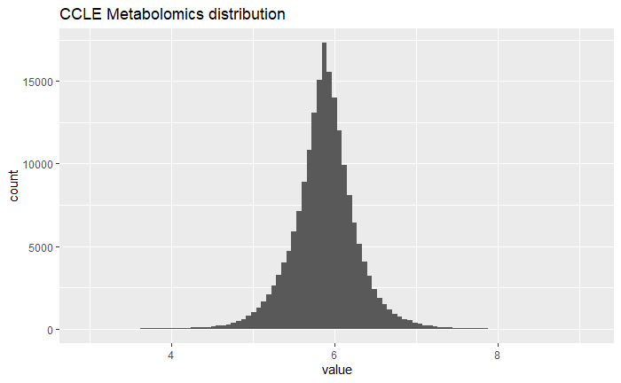

```r
ggplot(melt(met), aes(x=value)) +
  geom_histogram(bins=100) +
  ggtitle("CCLE Metabolomics distribution")
```

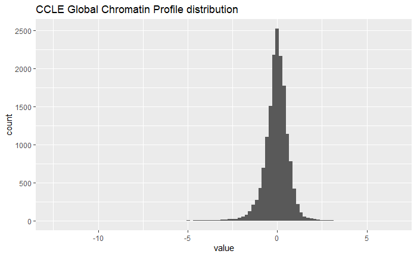

```r
ggplot(melt(gcp), aes(x=value)) +
  geom_histogram(bins=100) +
  ggtitle("CCLE Global Chromatin Profile distribution")
```

Also, I should remove NAs from the data

```r
gcp[is.na(gcp)] = 0
```

Now, let’s separate hematopoietic and leukemic stem cell lineages, just because they have different profiles.

```r
HL_idx = meta['Tissue'] == "HAEMATOPOIETIC AND LYMPHOID TISSUE"

# Solid only
gcp_noHL = gcp[-c(HL_idx), ]
met_noHL = met[-c(HL_idx), ]

# HL only
gcp_HL = gcp[c(HL_idx), ]
met_HL = met[c(HL_idx), ]

tissue = meta["Tissue"]
noHL_tissue = tissue[-c(HL_idx), 1]
HL_tissue = tissue[c(HL_idx), 1]
```